# Case study: asphalt

## The asphalt data

- 31 asphalt pavements prepared under different conditions. How does quality of pavement depend on these?
- Variables:
  - `pct.a.surf` Percentage of asphalt in surface layer
  - `pct.a.base` Percentage of asphalt in base layer
  - `fines` Percentage of fines in surface layer
  - `voids` Percentage of voids in surface layer
  - `rut.depth` Change in rut depth per million vehicle passes
  - `viscosity` Viscosity of asphalt
  - `run` 2 data collection periods: 1 for run 1, 0 for run 2.
- `rut.depth` response. Depends on other variables, how?

## Packages for this section

```r
library(MASS, exclude = "select")
library(tidyverse)
library(broom)
library(leaps)
```

Make sure to load `MASS` before `tidyverse` (for annoying technical reasons), or to load `MASS` excluding its `select` (as above).

## Getting set up

```r
my_url <- "http://ritsokiguess.site/datafiles/asphalt.txt"
asphalt <- read_delim(my_url, " ")
```

- Quantitative variables with one response: multiple regression.
- Some issues here that don’t come up in “simple” regression; handle as we go. (STAB27/STAC67 ideas.)

## The data (some)

```r
asphalt
```

| pct.a.surf | pct.a.base | fines | voids | rut.depth | viscosity | run |
| --- | --- | --- | --- | --- | --- | --- |
| 4.68 | 4.87 | 8.4 | 4.916 | 6.75 | 2.80 | 1 |
| 5.19 | 4.50 | 6.5 | 4.563 | 13.00 | 1.40 | 1 |
| 4.82 | 4.73 | 7.9 | 5.321 | 14.75 | 1.40 | 1 |
| 4.85 | 4.76 | 8.3 | 4.865 | 12.60 | 3.30 | 1 |
| 4.86 | 4.95 | 8.4 | 3.776 | 8.25 | 1.70 | 1 |
| 5.16 | 4.45 | 7.4 | 4.397 | 10.67 | 2.90 | 1 |
| 4.82 | 5.05 | 6.8 | 4.867 | 7.28 | 3.70 | 1 |
| 4.86 | 4.70 | 8.6 | 4.828 | 12.67 | 1.70 | 1 |
| 4.78 | 4.84 | 6.7 | 4.865 | 12.58 | 0.92 | 1 |
| 5.16 | 4.76 | 7.7 | 4.034 | 20.60 | 0.68 | 1 |

[output cut: 21 more lines]

## Plotting response “rut depth” against everything else

Same idea as for plotting separate predictions on one plot:

```r
asphalt %>%
  pivot_longer(
    -rut.depth,
    names_to="xname", values_to="x"
  ) %>%
  ggplot(aes(x = x, y = rut.depth)) + geom_point() +
  facet_wrap(~xname, scales = "free") -> g
```

“collect all the x-variables together into one column called x, with another column xname saying which x they were, then plot these x’s against rut.depth, a separate facet for each x-variable.”

I saved this graph to plot later (on the next page).

## The plot

```r
g
```

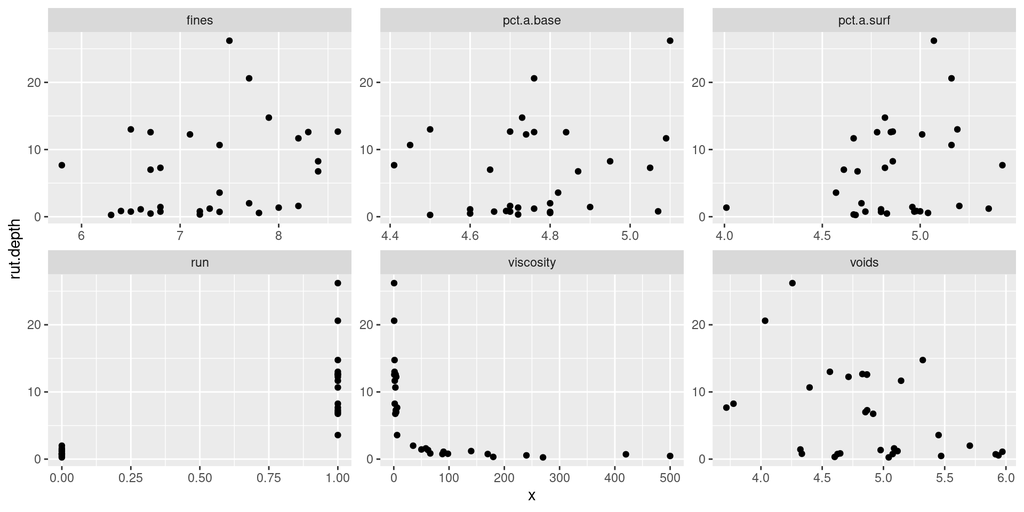

## Interpreting the plots

- One plot of rut depth against each of the six other variables.
- Get rough idea of what’s going on.
- Trends mostly weak.
- `viscosity` has strong but non-linear trend.
- `run` has effect but variability bigger when run is 1.
- Weak but downward trend for `voids`.
- Non-linearity of `rut.depth`-`viscosity` relationship should concern us.

## Log of `viscosity`: more nearly linear?

- Take this back to asphalt engineer: suggests log of `viscosity`:

```r
ggplot(asphalt, aes(y = rut.depth, x = log(viscosity))) +
  geom_point() + geom_smooth(se = FALSE) -> g
```

(plot overleaf)

## Rut depth against log-viscosity

```r
g
```

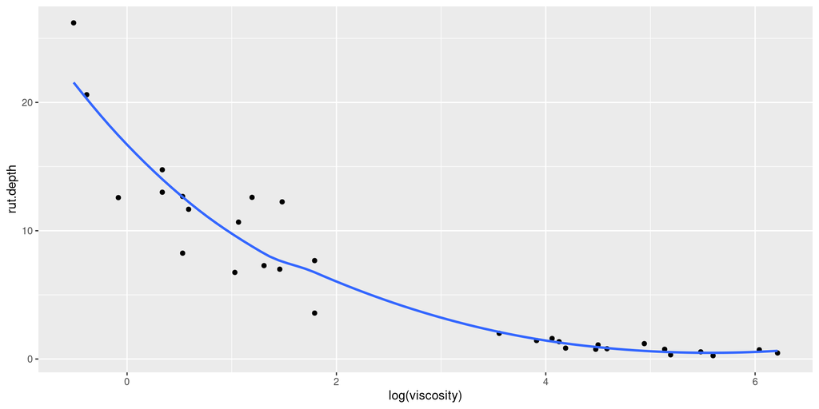

## Comments and next steps

- Not very linear, but better than before.
- In multiple regression, hard to guess which x’s affect response. So typically start by predicting from everything else.
- Model formula has response on left, squiggle, explanatories on right joined by plusses:

```r
rut.1 <- lm(rut.depth ~ pct.a.surf + pct.a.base + fines +
  voids + log(viscosity) + run, data = asphalt)
summary(rut.1)
```

```
Call:
lm(formula = rut.depth ~ pct.a.surf + pct.a.base + fines + voids +
    log(viscosity) + run, data = asphalt)

Residuals:
    Min      1Q  Median      3Q     Max
-4.1211 -1.9075 -0.7175  1.6382  9.5947

Coefficients:
               Estimate Std. Error t value Pr(>|t|)
(Intercept)    -12.9937    26.2188  -0.496   0.6247
pct.a.surf       3.9706     2.4966   1.590   0.1248
pct.a.base       1.2631     3.9703   0.318   0.7531
fines            0.1164     1.0124   0.115   0.9094
voids            0.5893     1.3244   0.445   0.6604
log(viscosity)  -3.1515     0.9194  -3.428   0.0022 **
run             -1.9655     3.6472  -0.539   0.5949
---
Signif. codes:  0 '***' 0.001 '**' 0.01 '*' 0.05 '.' 0.1 ' ' 1

Residual standard error: 3.324 on 24 degrees of freedom
Multiple R-squared:  0.806, Adjusted R-squared:  0.7575
F-statistic: 16.62 on 6 and 24 DF,  p-value: 1.743e-07
```

## Regression output: `summary(rut.1)` or:

```r
glance(rut.1)
```

| r.squared | adj.r.squared | sigma | statistic | p.value | df | logLik | AIC | BIC | deviance | df.residual | nobs |
| --- | --- | --- | --- | --- | --- | --- | --- | --- | --- | --- | --- |
| 0.8060035 | 0.7575043 | 3.323526 | 16.61893 | 1.743011e-07 | 6 | -77.25194 | 170.5039 | 181.9758 | 265.0998 | 24 | 31 |

```r
tidy(rut.1)
```

| term | estimate | std.error | statistic | p.value |
| --- | --- | --- | --- | --- |
| (Intercept) | -12.9936763 | 26.2187822 | -0.4955866 | 0.624693721 |
| pct.a.surf | 3.9705671 | 2.4966454 | 1.5903608 | 0.124841156 |
| pct.a.base | 1.2631409 | 3.9702906 | 0.3181482 | 0.753124397 |
| fines | 0.1164434 | 1.0123885 | 0.1150185 | 0.909387340 |
| voids | 0.5892602 | 1.3243933 | 0.4449284 | 0.660358431 |
| log(viscosity) | -3.1515128 | 0.9194468 | -3.4276183 | 0.002202725 |
| run | -1.9654795 | 3.6472048 | -0.5389002 | 0.594919790 |

## Comments

- R-squared 81%, not so bad.
- P-value in `glance` asserts that something helping to predict rut.depth.
- Table of coefficients says `log(viscosity)`.
- But confused by clearly non-significant variables: remove those to get clearer picture of what is helpful.

## Before we do anything, look at residual plots:

- 1. of residuals against fitted values (as usual)
- 2. of residuals against each explanatory.
- Problem fixes:
  - with (a): fix response variable;
  - with some plots in (b): fix those explanatory variables.

## Plot fitted values against residuals

```r
ggplot(rut.1, aes(x = .fitted, y = .resid)) + geom_point()
```

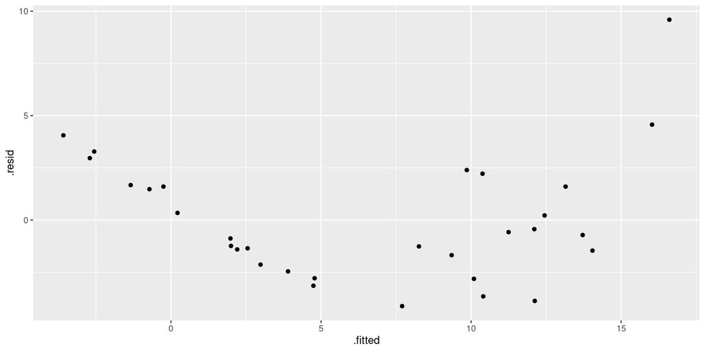

## Normal quantile plot of residuals

```r
ggplot(rut.1, aes(sample = .resid)) + stat_qq() + stat_qq_line()
```

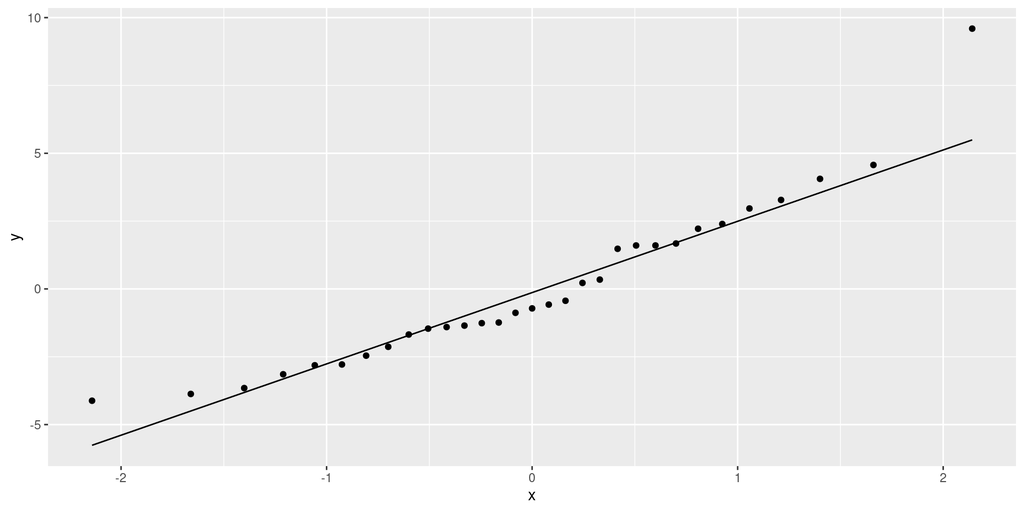

## Plotting residuals against $x$ variables

- Problem here is that residuals are in the fitted model, and the observed $x$-values are in the original data frame `asphalt`.
- Package broom contains a function `augment` that combines these two together so that they can later be plotted: start with a model first, and then augment with a data frame:

```r
rut.1 %>% augment(asphalt) -> rut.1a
rut.1a
```

| pct.a.surf | pct.a.base | fines | voids | rut.depth | viscosity | run | .fitted | .resid | .hat | .sigma | .cooksd | .std.resid |
| --- | --- | --- | --- | --- | --- | --- | --- | --- | --- | --- | --- | --- |
| 4.68 | 4.87 | 8.4 | 4.916 | 6.75 | 2.80 | 1 | 10.4046631 | -3.6546631 | 0.14428881 | 3.293545 | 0.0340389900 | -1.18873388 |
| 5.19 | 4.50 | 6.5 | 4.563 | 13.00 | 1.40 | 1 | 13.7175010 | -0.7175010 | 0.23695840 | 3.390685 | 0.0027097205 | -0.24714358 |
| 4.82 | 4.73 | 7.9 | 5.321 | 14.75 | 1.40 | 1 | 13.1485937 | 1.6014063 | 0.16306240 | 3.375330 | 0.0077210169 | 0.52669101 |
| 4.85 | 4.76 | 8.3 | 4.865 | 12.60 | 3.30 | 1 | 10.3812142 | 2.2187858 | 0.14373937 | 3.357991 | 0.0124824051 | 0.72146170 |
| 4.86 | 4.95 | 8.4 | 3.776 | 8.25 | 1.70 | 1 | 12.1212369 | -3.8712369 | 0.29401154 | 3.256246 | 0.1143332145 | -1.38628283 |
| 5.16 | 4.45 | 7.4 | 4.397 | 10.67 | 2.90 | 1 | 11.2471559 | -0.5771559 | 0.22462286 | 3.392256 | 0.0016096002 | -0.19721392 |
| 4.82 | 5.05 | 6.8 | 4.867 | 7.28 | 3.70 | 1 | 10.0943557 | -2.8143557 | 0.29024008 | 3.322782 | 0.0590195893 | -1.00513444 |
| 4.86 | 4.70 | 8.6 | 4.828 | 12.67 | 1.70 | 1 | 12.4486421 | 0.2213579 | 0.20105063 | 3.394615 | 0.0001996001 | 0.07451374 |
| 4.78 | 4.84 | 6.7 | 4.865 | 12.58 | 0.92 | 1 | 14.0434565 | -1.4634565 | 0.24901755 | 3.376697 | 0.0122302059 | -0.50811945 |
| 5.16 | 4.76 | 7.7 | 4.034 | 20.60 | 0.68 | 1 | 16.0306310 | 4.5693690 | 0.19023245 | 3.225683 | 0.0783393747 | 1.52783674 |

[output cut: 21 more lines]

## What does rut.1a contain?

```r
names(rut.1a)
```

```
 [1] "pct.a.surf" "pct.a.base" "fines"      "voids"      "rut.depth"
 [6] "viscosity"  "run"        ".fitted"    ".resid"     ".hat"
[11] ".sigma"     ".cooksd"    ".std.resid"
```

- all the stuff in original data frame, plus:
- quantities from regression (starting with a dot)

## Plotting residuals against $x$-variables

```r
rut.1a %>%
  mutate(log_vis=log(viscosity)) %>%
  pivot_longer(
    c(pct.a.surf:voids, run, log_vis),
    names_to="xname", values_to="x"
  ) %>%
  ggplot(aes(x = x, y = .resid)) +
  geom_point() + facet_wrap(~xname, scales = "free") -> g
```

## The plot

```r
g
```

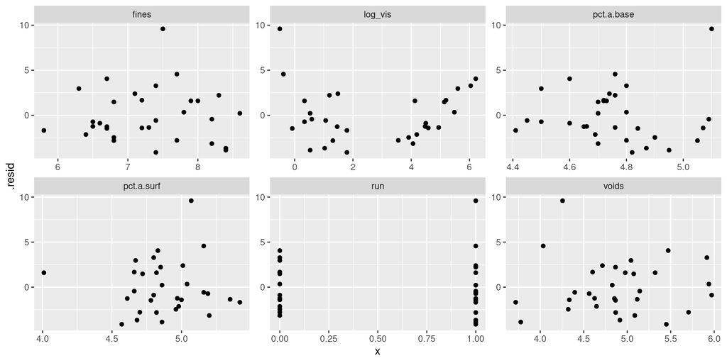

## Comments

- There is serious curve in plot of residuals vs. fitted values. Suggests a transformation of $y$.
- The residuals-vs-$x$’s plots don’t show any serious trends. Worst probably that potential curve against log-viscosity.
- Also, large positive residual, 10, that shows up on all plots. Perhaps transformation of $y$ will help with this too.
- If residual-fitted plot OK, but some residual-$x$ plots not, try transforming those $x$’s, eg. by adding $x^2$ to help with curve.

## Which transformation?

- Best way: consult with person who brought you the data.
- Can’t do that here!
- No idea what transformation would be good.
- Let data choose: “Box-Cox transformation”.
- Scale is that of “ladder of powers”: power transformation, but 0 is log.

## Running Box-Cox

From package `MASS`:

```r
boxcox(rut.depth ~ pct.a.surf + pct.a.base + fines + voids +
  log(viscosity) + run, data = asphalt)
```

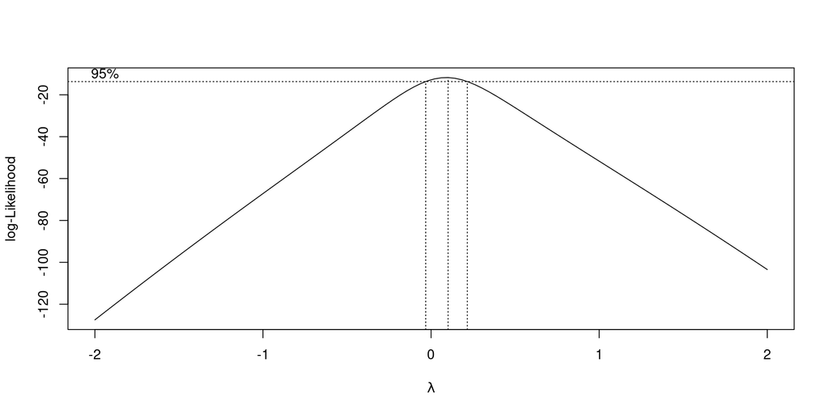

## Comments on Box-Cox plot

- $\lambda$ represents power to transform $y$ with.
- Best single choice of transformation parameter $\lambda$ is peak of curve, close to 0.
- Vertical dotted lines give CI for $\lambda$, about (−0.05, 0.2).
- $\lambda = 0$ means “log”.
- Narrowness of confidence interval mean that these not supported by data:
  - No transformation ($\lambda = 1$)
  - Square root ($\lambda = 0.5$)
  - Reciprocal ($\lambda = −1$).

## Relationships with explanatories

- As before: plot response (now `log(rut.depth)`) against other explanatory variables, all in one shot:

```r
asphalt %>%
  mutate(log_vis=log(viscosity)) %>%
  pivot_longer(
    c(pct.a.surf:voids, run, log_vis),
    names_to="xname", values_to="x"
  ) %>%
  ggplot(aes(y = log(rut.depth), x = x)) + geom_point() +
  facet_wrap(~xname, scales = "free") -> g3
```

## The new plots

```r
g3
```

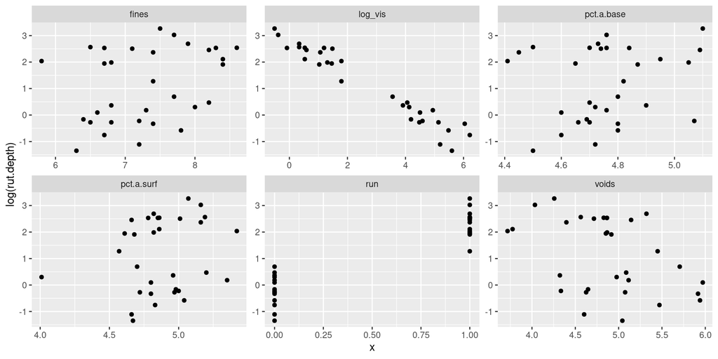

## Modelling with transformed response

- These trends look pretty straight, especially with `log.viscosity`.
- Values of `log.rut.depth` for each `run` have same spread.
- Other trends weak, but are straight if they exist.
- Start modelling from the beginning again.
- Model `log.rut.depth` in terms of everything else, see what can be removed:

```r
rut.2 <- lm(log(rut.depth) ~ pct.a.surf + pct.a.base +
  fines + voids + log(viscosity) + run, data = asphalt)
```

- use `tidy` from `broom` to display just the coefficients.

## Output

```r
tidy(rut.2)
```

| term | estimate | std.error | statistic | p.value |
| --- | --- | --- | --- | --- |
| (Intercept) | -1.57298922 | 2.43617401 | -0.6456802 | 5.246124e-01 |
| pct.a.surf | 0.58357559 | 0.23198113 | 2.5156167 | 1.898184e-02 |
| pct.a.base | -0.10336733 | 0.36890801 | -0.2801981 | 7.817265e-01 |
| fines | 0.09775203 | 0.09406823 | 1.0391609 | 3.090864e-01 |
| voids | 0.19885377 | 0.12305882 | 1.6159245 | 1.191815e-01 |
| log(viscosity) | -0.55768728 | 0.08543236 | -6.5278223 | 9.445184e-07 |
| run | 0.34004833 | 0.33888780 | 1.0034245 | 3.256663e-01 |

```r
summary(rut.2)
```

```
Call:
lm(formula = log(rut.depth) ~ pct.a.surf + pct.a.base + fines +
    voids + log(viscosity) + run, data = asphalt)

Residuals:
     Min       1Q   Median       3Q      Max
-0.53072 -0.18563 -0.00003  0.20017  0.55079

Coefficients:
               Estimate Std. Error t value Pr(>|t|)
(Intercept)    -1.57299    2.43617  -0.646    0.525
pct.a.surf      0.58358    0.23198   2.516    0.019 *
pct.a.base     -0.10337    0.36891  -0.280    0.782
fines           0.09775    0.09407   1.039    0.309
voids           0.19885    0.12306   1.616    0.119
log(viscosity) -0.55769    0.08543  -6.528 9.45e-07 ***
run             0.34005    0.33889   1.003    0.326
---
Signif. codes:  0 '***' 0.001 '**' 0.01 '*' 0.05 '.' 0.1 ' ' 1

Residual standard error: 0.3088 on 24 degrees of freedom
Multiple R-squared:  0.961, Adjusted R-squared:  0.9512
F-statistic: 98.47 on 6 and 24 DF,  p-value: 1.059e-15
```

## Taking out everything non-significant

- Try: remove everything but pct.a.surf and log.viscosity:

```r
rut.3 <- lm(log(rut.depth) ~ pct.a.surf + log(viscosity), data = asphalt)
summary(rut.3)
```

```
Call:
lm(formula = log(rut.depth) ~ pct.a.surf + log(viscosity), data = asphalt)

Residuals:
     Min       1Q   Median       3Q      Max
-0.61938 -0.21361  0.06635  0.14932  0.63012

Coefficients:
               Estimate Std. Error t value Pr(>|t|)
(Intercept)     0.90014    1.08059   0.833   0.4119
pct.a.surf      0.39115    0.21879   1.788   0.0846 .
log(viscosity) -0.61856    0.02713 -22.797   <2e-16 ***
---
Signif. codes:  0 '***' 0.001 '**' 0.01 '*' 0.05 '.' 0.1 ' ' 1

Residual standard error: 0.3208 on 28 degrees of freedom
Multiple R-squared:  0.9509,    Adjusted R-squared:  0.9474
F-statistic: 270.9 on 2 and 28 DF,  p-value: < 2.2e-16
```

- Check that removing all those variables wasn’t too much:

```r
anova(rut.3, rut.2)
```

|  | Res.Df | RSS | Df | Sum of Sq | F | Pr(>F) |
| --- | --- | --- | --- | --- | --- | --- |
| 1 | 28 | 2.880919 | NA | NA | NA | NA |
| 2 | 24 | 2.288764 | 4 | 0.5921551 | 1.552336 | 0.2191461 |

- $H_0$ : two models equally good; $H_a$ : bigger model better.
- Null not rejected here; small model as good as the big one, so prefer simpler smaller model `rut.3`.

## Find the largest P-value by eye:

```r
tidy(rut.2)
```

| term | estimate | std.error | statistic | p.value |
| --- | --- | --- | --- | --- |
| (Intercept) | -1.57298922 | 2.43617401 | -0.6456802 | 5.246124e-01 |
| pct.a.surf | 0.58357559 | 0.23198113 | 2.5156167 | 1.898184e-02 |
| pct.a.base | -0.10336733 | 0.36890801 | -0.2801981 | 7.817265e-01 |
| fines | 0.09775203 | 0.09406823 | 1.0391609 | 3.090864e-01 |
| voids | 0.19885377 | 0.12305882 | 1.6159245 | 1.191815e-01 |
| log(viscosity) | -0.55768728 | 0.08543236 | -6.5278223 | 9.445184e-07 |
| run | 0.34004833 | 0.33888780 | 1.0034245 | 3.256663e-01 |

```r
summary(rut.2)
```

```
Call:
lm(formula = log(rut.depth) ~ pct.a.surf + pct.a.base + fines +
    voids + log(viscosity) + run, data = asphalt)

Residuals:
     Min       1Q   Median       3Q      Max
-0.53072 -0.18563 -0.00003  0.20017  0.55079

Coefficients:
               Estimate Std. Error t value Pr(>|t|)
(Intercept)    -1.57299    2.43617  -0.646    0.525
pct.a.surf      0.58358    0.23198   2.516    0.019 *
pct.a.base     -0.10337    0.36891  -0.280    0.782
fines           0.09775    0.09407   1.039    0.309
voids           0.19885    0.12306   1.616    0.119
log(viscosity) -0.55769    0.08543  -6.528 9.45e-07 ***
run             0.34005    0.33889   1.003    0.326
---
Signif. codes:  0 '***' 0.001 '**' 0.01 '*' 0.05 '.' 0.1 ' ' 1

Residual standard error: 0.3088 on 24 degrees of freedom
Multiple R-squared:  0.961, Adjusted R-squared:  0.9512
F-statistic: 98.47 on 6 and 24 DF,  p-value: 1.059e-15
```

- Largest P-value is 0.78 for `pct.a.base`, not significant.
- So remove this first, re-fit and re-assess.
- Or, as over.

## Get the computer to find the largest P-value for you

- Output from `tidy` is itself a data frame, thus:

```r
tidy(rut.2) %>% arrange(p.value)
```

| term | estimate | std.error | statistic | p.value |
| --- | --- | --- | --- | --- |
| log(viscosity) | -0.55768728 | 0.08543236 | -6.5278223 | 9.445184e-07 |
| pct.a.surf | 0.58357559 | 0.23198113 | 2.5156167 | 1.898184e-02 |
| voids | 0.19885377 | 0.12305882 | 1.6159245 | 1.191815e-01 |
| fines | 0.09775203 | 0.09406823 | 1.0391609 | 3.090864e-01 |
| run | 0.34004833 | 0.33888780 | 1.0034245 | 3.256663e-01 |
| (Intercept) | -1.57298922 | 2.43617401 | -0.6456802 | 5.246124e-01 |
| pct.a.base | -0.10336733 | 0.36890801 | -0.2801981 | 7.817265e-01 |

- Largest P-value at the bottom.

## Take out `pct.a.base`

- Copy and paste the `lm` code and remove what you’re removing:

```r
rut.4 <- lm(log(rut.depth) ~ pct.a.surf + fines + voids +
              log(viscosity) + run, data = asphalt)
summary(rut.4)
```

```
Call:
lm(formula = log(rut.depth) ~ pct.a.surf + fines + voids + log(viscosity) +
    run, data = asphalt)

Residuals:
     Min       1Q   Median       3Q      Max
-0.51610 -0.18785 -0.02248  0.18364  0.57160

Coefficients:
               Estimate Std. Error t value Pr(>|t|)
(Intercept)    -2.07850    1.60665  -1.294   0.2076
pct.a.surf      0.59299    0.22526   2.632   0.0143 *
fines           0.08895    0.08701   1.022   0.3165
voids           0.20047    0.12064   1.662   0.1091
log(viscosity) -0.55249    0.08184  -6.751 4.48e-07 ***
run             0.35977    0.32533   1.106   0.2793
---
Signif. codes:  0 '***' 0.001 '**' 0.01 '*' 0.05 '.' 0.1 ' ' 1

Residual standard error: 0.3031 on 25 degrees of freedom
Multiple R-squared:  0.9608,    Adjusted R-squared:  0.953
F-statistic: 122.7 on 5 and 25 DF,  p-value: < 2.2e-16
```

```r
tidy(rut.4) %>% arrange(p.value) %>% dplyr::select(term, p.value)
```

| term | p.value |
| --- | --- |
| log(viscosity) | 4.483621e-07 |
| pct.a.surf | 1.432182e-02 |
| voids | 1.090561e-01 |
| (Intercept) | 2.075999e-01 |
| run | 2.793085e-01 |
| fines | 3.164725e-01 |

- `fines` is next to go, P-value 0.32.

## “Update”

Another way to do the same thing:

```r
rut.4 <- update(rut.2, . ~ . - pct.a.base)
summary(rut.4)
```

```
Call:
lm(formula = log(rut.depth) ~ pct.a.surf + fines + voids + log(viscosity) +
    run, data = asphalt)

Residuals:
     Min       1Q   Median       3Q      Max
-0.51610 -0.18785 -0.02248  0.18364  0.57160

Coefficients:
               Estimate Std. Error t value Pr(>|t|)
(Intercept)    -2.07850    1.60665  -1.294   0.2076
pct.a.surf      0.59299    0.22526   2.632   0.0143 *
fines           0.08895    0.08701   1.022   0.3165
voids           0.20047    0.12064   1.662   0.1091
log(viscosity) -0.55249    0.08184  -6.751 4.48e-07 ***
run             0.35977    0.32533   1.106   0.2793
---
Signif. codes:  0 '***' 0.001 '**' 0.01 '*' 0.05 '.' 0.1 ' ' 1

Residual standard error: 0.3031 on 25 degrees of freedom
Multiple R-squared:  0.9608,    Adjusted R-squared:  0.953
F-statistic: 122.7 on 5 and 25 DF,  p-value: < 2.2e-16
```

```r
tidy(rut.4) %>% arrange(p.value)
```

| term | estimate | std.error | statistic | p.value |
| --- | --- | --- | --- | --- |
| log(viscosity) | -0.55249041 | 0.08184342 | -6.750578 | 4.483621e-07 |
| pct.a.surf | 0.59299473 | 0.22526263 | 2.632459 | 1.432182e-02 |
| voids | 0.20046739 | 0.12063727 | 1.661737 | 1.090561e-01 |
| (Intercept) | -2.07849871 | 1.60665073 | -1.293684 | 2.075999e-01 |
| run | 0.35977353 | 0.32532859 | 1.105877 | 2.793085e-01 |
| fines | 0.08894579 | 0.08701332 | 1.022209 | 3.164725e-01 |

- Again, `fines` is the one to go. (Output identical as it should be.)

## Take out fines:

```r
rut.5 <- update(rut.4, . ~ . - fines)
summary(rut.5)
```

```
Call:
lm(formula = log(rut.depth) ~ pct.a.surf + voids + log(viscosity) +
    run, data = asphalt)

Residuals:
     Min       1Q   Median       3Q      Max
-0.57275 -0.20080  0.01061  0.17711  0.59774

Coefficients:
               Estimate Std. Error t value Pr(>|t|)
(Intercept)    -1.25533    1.39147  -0.902   0.3753
pct.a.surf      0.54837    0.22118   2.479   0.0200 *
voids           0.23188    0.11676   1.986   0.0577 .
log(viscosity) -0.58039    0.07723  -7.516 5.59e-08 ***
run             0.29468    0.31931   0.923   0.3646
---
Signif. codes:  0 '***' 0.001 '**' 0.01 '*' 0.05 '.' 0.1 ' ' 1

Residual standard error: 0.3033 on 26 degrees of freedom
Multiple R-squared:  0.9592,    Adjusted R-squared:  0.9529
F-statistic: 152.8 on 4 and 26 DF,  p-value: < 2.2e-16
```

```r
tidy(rut.5) %>% arrange(p.value) %>% dplyr::select(term, p.value)
```

| term | p.value |
| --- | --- |
| log(viscosity) | 5.591602e-08 |
| pct.a.surf | 1.997130e-02 |
| voids | 5.767397e-02 |
| run | 3.645654e-01 |
| (Intercept) | 3.752525e-01 |

Can’t take out intercept, so `run`, with P-value 0.36, goes next.

## Take out run:

```r
rut.6 <- update(rut.5, . ~ . - run)
summary(rut.6)
```

```
Call:
lm(formula = log(rut.depth) ~ pct.a.surf + voids + log(viscosity),
    data = asphalt)

Residuals:
     Min       1Q   Median       3Q      Max
-0.53548 -0.20181 -0.01702  0.16748  0.54707

Coefficients:
               Estimate Std. Error t value Pr(>|t|)
(Intercept)    -1.02079    1.36430  -0.748   0.4608
pct.a.surf      0.55547    0.22044   2.520   0.0180 *
voids           0.24479    0.11560   2.118   0.0436 *
log(viscosity) -0.64649    0.02879 -22.458   <2e-16 ***
---
Signif. codes:  0 '***' 0.001 '**' 0.01 '*' 0.05 '.' 0.1 ' ' 1

Residual standard error: 0.3025 on 27 degrees of freedom
Multiple R-squared:  0.9579,    Adjusted R-squared:  0.9532
F-statistic: 204.6 on 3 and 27 DF,  p-value: < 2.2e-16
```

```r
tidy(rut.6) %>% arrange(p.value) %>% dplyr::select(term, p.value)
```

| term | p.value |
| --- | --- |
| log(viscosity) | 5.288267e-19 |
| pct.a.surf | 1.796333e-02 |
| voids | 4.356036e-02 |
| (Intercept) | 4.607966e-01 |

Again, can’t take out intercept, so largest P-value is for `voids`, 0.044. But this is significant, so we shouldn’t remove `voids`.

## Comments

- Here we stop: `pct.a.surf`, `voids` and `log.viscosity` would all make fit significantly worse if removed. So they stay.
- Different final result from taking things out one at a time (top), than by taking out 4 at once (bottom):

```r
summary(rut.6)
```

```
Call:
lm(formula = log(rut.depth) ~ pct.a.surf + voids + log(viscosity),
    data = asphalt)

Residuals:
     Min       1Q   Median       3Q      Max
-0.53548 -0.20181 -0.01702  0.16748  0.54707

Coefficients:
               Estimate Std. Error t value Pr(>|t|)
(Intercept)    -1.02079    1.36430  -0.748   0.4608
pct.a.surf      0.55547    0.22044   2.520   0.0180 *
voids           0.24479    0.11560   2.118   0.0436 *
log(viscosity) -0.64649    0.02879 -22.458   <2e-16 ***
---
Signif. codes:  0 '***' 0.001 '**' 0.01 '*' 0.05 '.' 0.1 ' ' 1

Residual standard error: 0.3025 on 27 degrees of freedom
Multiple R-squared:  0.9579,    Adjusted R-squared:  0.9532
F-statistic: 204.6 on 3 and 27 DF,  p-value: < 2.2e-16
```

```r
coef(rut.6)
```

```
   (Intercept)     pct.a.surf          voids log(viscosity)
    -1.0207945      0.5554686      0.2447934     -0.6464911
```

```r
coef(rut.3)
```

```
   (Intercept)     pct.a.surf log(viscosity)
     0.9001389      0.3911481     -0.6185628
```

- Point: Can make difference which way we go.

## Comments on variable selection

- Best way to decide which $x$’s belong: expert knowledge: which of them should be important.
- Best automatic method: what we did, “backward selection”.
- Do not learn about “stepwise regression”! [**eg. here**](https://towardsdatascience.com/stopping-stepwise-why-stepwise-selection-is-bad-and-what-you-should-use-instead-90818b3f52df)
- R has function `step` that does backward selection, like this:

```r
step(rut.2, direction = "backward", test = "F")
```

[output not shown]

Gets same answer as we did (by removing least significant x).

- Removing non-significant $x$’s may remove interesting ones whose P-values happened not to reach 0.05. Consider using less stringent cutoff like 0.20 or even bigger.
- Can also fit all possible regressions, as over (may need to do `install.packages("leaps")` first).

## All possible regressions (output over)

Uses package `leaps`:

```r
leaps <- regsubsets(log(rut.depth) ~ pct.a.surf +
                      pct.a.base + fines + voids +
                      log(viscosity) + run,
                    data = asphalt, nbest = 2)
s <- summary(leaps)
with(s, data.frame(rsq, outmat)) -> d
```

## The output

```r
d %>% rownames_to_column("model") %>% arrange(desc(rsq))
```

| model | rsq | pct.a.surf | pct.a.base | fines | voids | log.viscosity. | run |
| --- | --- | --- | --- | --- | --- | --- | --- |
| 6 ( 1 ) | 0.9609642 | * | * | * | * | * | * |
| 5 ( 1 ) | 0.9608365 | * |  | * | * | * | * |
| 5 ( 2 ) | 0.9593265 | * | * | * | * | * |  |
| 4 ( 1 ) | 0.9591996 | * |  |  | * | * | * |
| 4 ( 2 ) | 0.9589206 | * |  | * | * | * |  |
| 3 ( 1 ) | 0.9578631 | * |  |  | * | * |  |
| 3 ( 2 ) | 0.9534561 | * |  | * |  | * |  |
| 2 ( 1 ) | 0.9508647 | * |  |  |  | * |  |
| 2 ( 2 ) | 0.9479541 |  |  |  | * | * |  |
| 1 ( 1 ) | 0.9452562 |  |  |  |  | * |  |

[output cut: 1 more lines]

## All possible regressions, adjusted R-squared

```r
with(s, data.frame(adjr2, outmat)) %>%
  rownames_to_column("model") %>%
  arrange(desc(adjr2))
```

| model | adjr2 | pct.a.surf | pct.a.base | fines | voids | log.viscosity. | run |
| --- | --- | --- | --- | --- | --- | --- | --- |
| 3 ( 1 ) | 0.9531812 | * |  |  | * | * |  |
| 5 ( 1 ) | 0.9530038 | * |  | * | * | * | * |
| 4 ( 1 ) | 0.9529226 | * |  |  | * | * | * |
| 4 ( 2 ) | 0.9526007 | * |  | * | * | * |  |
| 6 ( 1 ) | 0.9512052 | * | * | * | * | * | * |
| 5 ( 2 ) | 0.9511918 | * | * | * | * | * |  |
| 3 ( 2 ) | 0.9482845 | * |  | * |  | * |  |
| 2 ( 1 ) | 0.9473550 | * |  |  |  | * |  |
| 2 ( 2 ) | 0.9442365 |  |  |  | * | * |  |
| 1 ( 1 ) | 0.9433685 |  |  |  |  | * |  |

[output cut: 1 more lines]

## Revisiting the best model

- Best model was our rut.6:

```r
tidy(rut.6)
```

| term | estimate | std.error | statistic | p.value |
| --- | --- | --- | --- | --- |
| (Intercept) | -1.0207945 | 1.36430001 | -0.7482185 | 4.607966e-01 |
| pct.a.surf | 0.5554686 | 0.22044153 | 2.5198000 | 1.796333e-02 |
| voids | 0.2447934 | 0.11559805 | 2.1176259 | 4.356036e-02 |
| log(viscosity) | -0.6464911 | 0.02878643 | -22.4581853 | 5.288267e-19 |

```r
summary(rut.6)
```

```
Call:
lm(formula = log(rut.depth) ~ pct.a.surf + voids + log(viscosity),
    data = asphalt)

Residuals:
     Min       1Q   Median       3Q      Max
-0.53548 -0.20181 -0.01702  0.16748  0.54707

Coefficients:
               Estimate Std. Error t value Pr(>|t|)
(Intercept)    -1.02079    1.36430  -0.748   0.4608
pct.a.surf      0.55547    0.22044   2.520   0.0180 *
voids           0.24479    0.11560   2.118   0.0436 *
log(viscosity) -0.64649    0.02879 -22.458   <2e-16 ***
---
Signif. codes:  0 '***' 0.001 '**' 0.01 '*' 0.05 '.' 0.1 ' ' 1

Residual standard error: 0.3025 on 27 degrees of freedom
Multiple R-squared:  0.9579,    Adjusted R-squared:  0.9532
F-statistic: 204.6 on 3 and 27 DF,  p-value: < 2.2e-16
```

## Revisiting (2)

- Regression slopes say that rut depth increases as log-viscosity decreases, `pct.a.surf` increases and `voids` increases. This more or less checks out with out scatterplots against `log.viscosity`.
- We should check residual plots again, though previous scatterplots say it’s unlikely that there will be a problem:

```r
g <- ggplot(rut.6, aes(y = .resid, x = .fitted)) +
geom_point()
```

## Residuals against fitted values

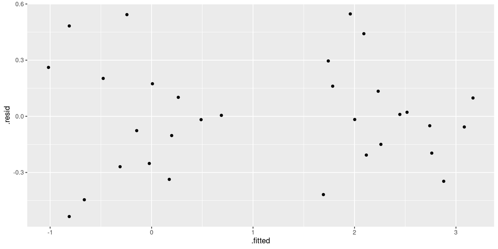

```r
g
```

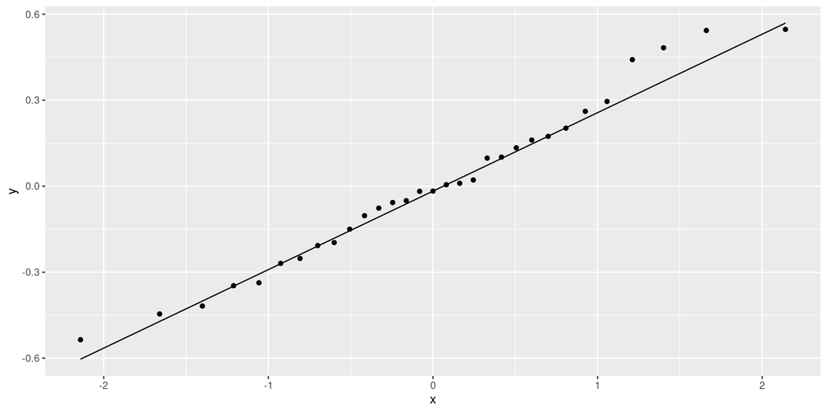

```r
ggplot(rut.6, aes(sample = .resid)) + stat_qq() + stat_qq_line()
```

## Plotting residuals against x’s

- Do our trick again to put them all on one plot:

```r
augment(rut.6, asphalt) %>%
  mutate(log_vis=log(viscosity)) %>%
  pivot_longer(
    c(pct.a.surf:voids, run, log_vis),
    names_to="xname", values_to="x",
  ) %>%
  ggplot(aes(y = .resid, x = x)) + geom_point() +
  facet_wrap(~xname, scales = "free") -> g2
```

## Residuals against the x’s

```r
g2
```

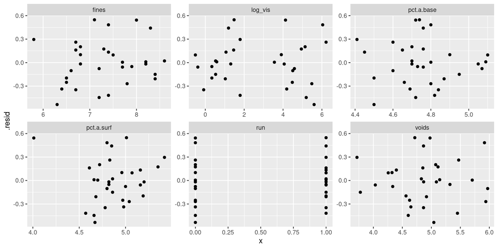

## Comments

- None of the plots show any sort of pattern. The points all look random on each plot.
- On the plot of fitted values (and on the one of log.viscosity), the points seem to form a “left half” and a “right half” with a gap in the middle. This is not a concern.
- One of the pct.a.surf values is low outlier (4), shows up top left of that plot.
- Only two possible values of run; the points in each group look randomly scattered around 0, with equal spreads.
- Residuals seem to go above zero further than below, suggesting a mild non-normality, but not enough to be a problem.

## Variable-selection strategies

- Expert knowledge.
- Backward elimination.
- All possible regressions.
- Taking a variety of models to experts and asking their opinion.
- Use a looser cutoff to eliminate variables in backward elimination (eg. only if P-value greater than 0.20).
- If goal is prediction, eliminating worthless variables less important.
- If goal is understanding, want to eliminate worthless variables where possible.
- Results of variable selection not always reproducible, so caution advised.